# Индивидуальный проект этап № 2

Установка DVWA

Мальянц Виктория Кареновна

1132246740@rudn.ru

Российский университет дружбы народов

2026-03-02

# Цель работы

- Приобретение практических навыков по установке DVWA.

# Задание

- Установить DVWA на дистрибутив Kali Linux

# Выполнение лабораторной работы

## Установить DVWA на дистрибутив Kali Linux

- Перехожу в директорию /var/www/html, после этого клонирую нужный репозиторий GitHub (рис. 1).

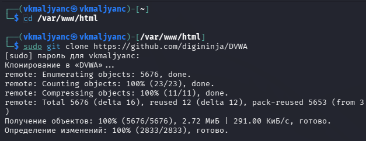

Клонирование репозитория в нужной директории

## Установить DVWA на дистрибутив Kali Linux

- Убеждаюсь в успешном клонировании репозитория и повышаю права доступа к этой директории до 777 (рис. 2).

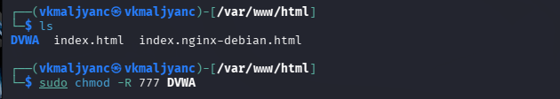

Просмотр содержимого директории и повышение прав доступа

## Установить DVWA на дистрибутив Kali Linux

- Перехожу в каталог DVWA/config и просматриваю его содержимое (рис. 3).

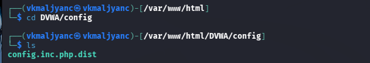

Переход в каталог DVWA/config и просмотр его содержимого

## Установить DVWA на дистрибутив Kali Linux

- Копирую файл config.inc.php.dist с именем config.inc.php (рис. 4).

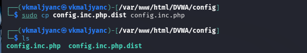

Копирование файла config.inc.php.dist с именем config.inc.php

## Установить DVWA на дистрибутив Kali Linux

- Редактирую файл config.inc.php, изменяю данные об имени пользователя и пароле (рис. 6).

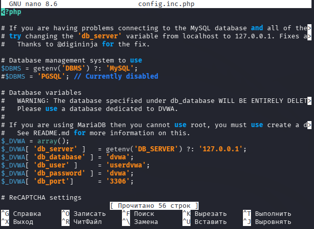

Редактирование файла config.inc.php

## Установить DVWA на дистрибутив Kali Linux

- Запускаю mysql и выполняю проверку, чтобы узнать, запущен ли процесс (рис. 7).

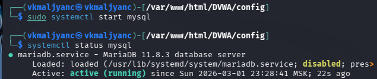

Запуск mysql и проверка запуска процесса

## Установить DVWA на дистрибутив Kali Linux

- Авторизуюсь в базе данных от имени пользователя root, создаю нового пользователя в командной строке с приглашением “MariaDB”, используя данные из config.inc.php (рис. 8).

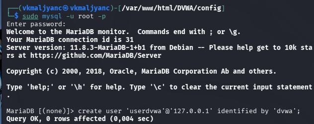

Авторизация в базе данных от имени пользователя root и создание нового пользователя

## Установить DVWA на дистрибутив Kali Linux

- Предоставляю пользователю привилегии для работы с этой базой данных (рис. 9).

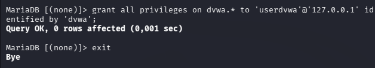

Предоставление пользователю привилегий для работы с этой базой данных

## Установить DVWA на дистрибутив Kali Linux

- Перехожу в директорию /etc/php/8.4/apache2 (рис. 10).

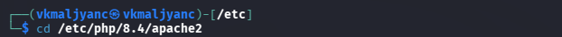

Переход в директорию /etc/php/8.4/apache2

## Установить DVWA на дистрибутив Kali Linux

- Открываю в текстовом редакторе nano файл php.ini (рис. 11).

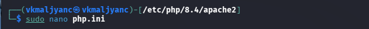

Открытие в текстовом редакторе nano файла php.ini

## Установить DVWA на дистрибутив Kali Linux

- Ставлю параметры allow_url_fopen и allow_url_include как On (рис. 12).

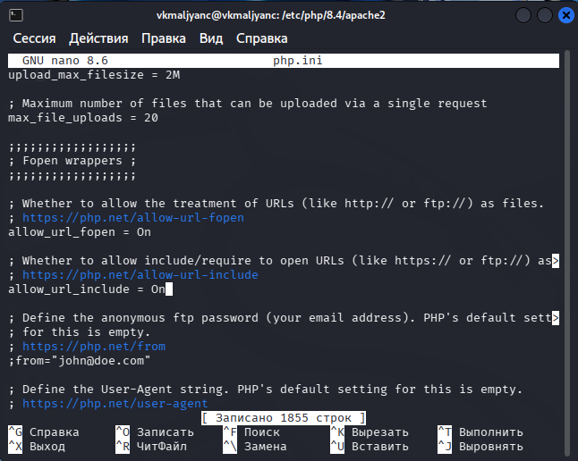

Выставление параметров allow_url_fopen и allow_url_include как On

## Установить DVWA на дистрибутив Kali Linux

- Запускаю службу веб-сервера apache и проверяю, запущена ли служба (рис. 13).

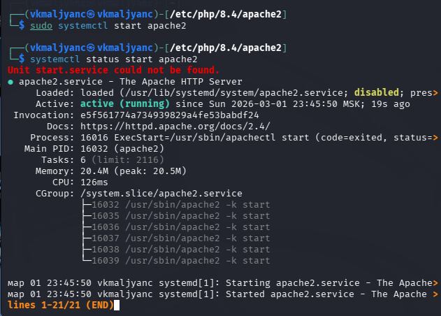

Запуск службы веб-сервера apache

## Установить DVWA на дистрибутив Kali Linux

- Я настроила DVWA, базу данных и Apache. Открываю браузер и запускаю веб-приложение, введя 127.0.0.1.DVWA (рис. 14).

[figure not shown]

Открытие браузера и запуск веб-приложения

## Установить DVWA на дистрибутив Kali Linux

- Нажимаю на кнопку Create / Reset Database (рис. 15).

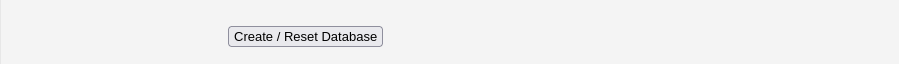

Нажатие кнопки Create / Reset Database

## Установить DVWA на дистрибутив Kali Linux

- Авторизуюсь с помощью предложенных по умолчанию данных (рис. 16).

[figure not shown]

Авторизация

## Установить DVWA на дистрибутив Kali Linux

- Оказываюсь на домашней странице веб-приложения (рис. 17).

[figure not shown]

Домашняя страница веб-приложения

# Выводы

- Я приобрела практические навыки по установке DVWA.

# Спасибо за внимание